# PEC2 - Estudio de Técnicas de Visualización de Datos

Miguel Ángel Sosvilla Luis

Abril 2022

**Configuración y carga de paquetes**

Cargamos los paquetes necesarios para el análisis.

```r
library(dplyr)
library(tidyr)
library(openxlsx)
library(ggplot2)
library(scales)
library(GGally)
library(hrbrthemes)
library(viridis)
```

Establecemos las configuraciones comunes del tema que usaremos en los gráficos.

```r
theme_set(theme_ipsum(base_size=12) +
          theme(axis.title.x = element_text(size = 11),
                axis.title.y = element_text(size = 11)))
```

# 1 Heatmap

Usaremos el heatmap o mapa de calor para mostrar la distribución por meses y comunidades autónomas de los incendios en España.

## 1.1 Carga y preparación de los datos

Usamos el conjunto de datos [Todos los incendios forestales](https://datos.civio.es/dataset/todos-los-incendios-forestales) de la [Fundación Civio](https://civio.es/) que contiene información detallada sobre cada uno de los incendios forestales acontecidos en España entre 2001 y 2015.

```r
original_fires <- read.csv("datasets/fires-all.csv",
                  head = TRUE,
                  colClasses = c("fecha"="Date"),
                  stringsAsFactors = FALSE,
                  blank.lines.skip = TRUE)

str(original_fires)
```

```
## 'data.frame':    82640 obs. of  21 variables:
##  $ id             : int  2001010001 2001010004 2001010005 2001010008 2001010017 2001010018 2001010020 2001010021 2001010024 2001010026 ...
##  $ superficie     : num  3.7 1.5 1.5 7.5 1.04 ...
##  $ fecha          : Date, format: "2001-03-18" "2001-03-24" ...
##  $ lat            : num  43 42.6 48.3 42.9 43.1 ...
##  $ lng            : num  -2.33 -2.64 -3.4 -2.49 -3.02 ...
##  $ latlng_explicit: int  1 1 1 1 1 1 1 1 1 1 ...
##  $ idcomunidad    : int  1 1 1 1 1 1 1 1 1 1 ...
##  $ idprovincia    : int  1 1 1 1 1 1 1 1 1 1 ...
##  $ idmunicipio    : int  13 41 33 13 10 43 60 31 43 63 ...
##  $ municipio      : chr  "BARRUNDIA" "NAVARIDAS" "LAPUEBLA DE LABARCA" "BARRUNDIA" ...
##  $ causa          : int  4 2 2 4 5 2 5 4 2 4 ...
##  $ causa_supuesta : int  NA 1 NA NA NA 1 NA 1 1 NA ...
##  $ causa_desc     : int  2 10 10 2 0 60 0 2 20 0 ...
##  $ muertos        : int  NA NA NA NA NA NA NA NA NA NA ...
##  $ heridos        : int  NA NA NA NA NA NA NA NA NA NA ...
##  $ time_ctrl      : int  150 275 135 335 45 135 130 240 85 205 ...
##  $ time_ext       : int  180 290 165 410 75 180 280 420 200 260 ...
##  $ personal       : int  10 4 4 6 11 12 26 38 14 28 ...
##  $ medios         : int  2 1 1 1 2 1 6 4 3 2 ...
##  $ gastos         : int  661 661 312 1082 270 703 2140 2711 1046 1809 ...
##  $ perdidas       : int  553 451 902 15338 2866 1340 22982 13361 2927 13649 ...
```

Cargamos tablas con datos geográficos que usaremos para mostrar la información de los incendios por comunidad autónoma y ordenados por latitud de las capitales.

```r
regions_codes <- read.xlsx("datasets/eell-extra-codes.xlsx", "regions")
datos_geograficos <- read.xlsx("datasets/eell-extra-codes.xlsx", "datos_geograficos_capitales")

comunidades <- regions_codes %>% select(idcomunidad, nombre_comunidad) %>% distinct()
latitudes <- datos_geograficos %>% group_by(idcomunidad) %>%
                                   summarise(latitud = max(Lat.ETRS89)) %>%
                                   left_join(comunidades, by = c("idcomunidad"))

comunidades_por_latitud <- latitudes %>% arrange(latitud) %>% select(nombre_comunidad)
```

Creo el conjunto de datos a visualizar con el porcentaje de superficie quedada cada mes (sobre el total de la superficie quemada) en cada comunidad autónoma.

```r
fires <- original_fires
fires$fecha <- as.Date(original_fires$fecha)
fires$mes <- factor(format(fires$fecha,"%m"),
                    labels=c("Enero", "Febrero", "Marzo", "Abril",
                             "Mayo", "Junio", "Julio", "Agosto",
                             "Septiembre", "Octubre", "Noviembre", "Diciembre"))

fires <- fires %>% left_join(select(regions_codes,
                                    idprovincia,
                                    nombre_comunidad,
                                    nombre_provincia),
                             by="idprovincia") %>%
                   select(fecha, mes, nombre_comunidad, superficie)

incendios_mes <- fires %>% group_by(nombre_comunidad, mes) %>%
                           summarise(numero_incendios = n(),
                                     superficie = sum(superficie),
                                     .groups = 'drop') %>%
                           group_by(nombre_comunidad) %>%
                           mutate(porcentaje_superficie = round(superficie / sum(superficie), 3),
                                  porcentaje_numero_incendios =
                                    round(numero_incendios / sum(numero_incendios), 3)) %>%
                          ungroup()

str(incendios_mes)
```

```
## tibble [208 × 6] (S3: tbl_df/tbl/data.frame)
##  $ nombre_comunidad           : chr [1:208] "Andalucía" "Andalucía" "Andalucía" "Andalucía" ...
##  $ mes                        : Factor w/ 12 levels "Enero","Febrero",..: 1 2 3 4 5 6 7 8 9 10 ...
##  $ numero_incendios           : int [1:208] 68 133 139 142 276 784 1215 1024 544 276 ...
##  $ superficie                 : num [1:208] 424 1506 3921 2232 2657 ...
##  $ porcentaje_superficie      : num [1:208] 0.003 0.009 0.024 0.014 0.016 0.11 0.474 0.264 0.053 0.014 ...
##  $ porcentaje_numero_incendios: num [1:208] 0.014 0.028 0.029 0.03 0.058 0.166 0.257 0.216 0.115 0.058 ...
```

## 1.2 Visualización

Mostramos en un mapa de calor el porcentaje de superficie quemada en cada mes sobre el total de superficie quemada.

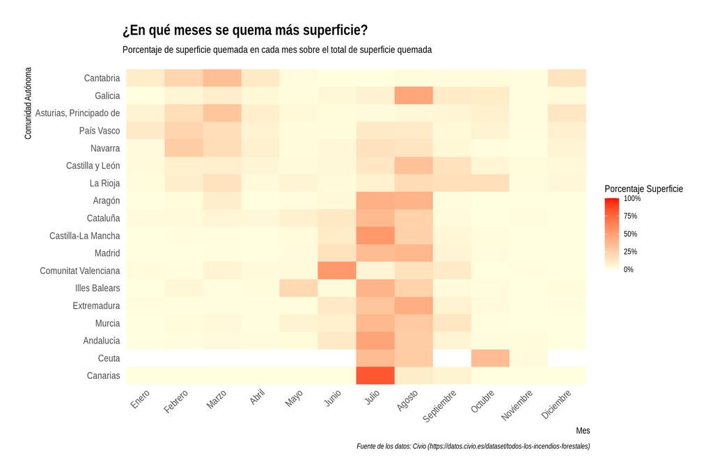

```r
heatmap <- incendios_mes %>% ggplot(aes(x=mes, y=factor(nombre_comunidad, levels=comunidades_por_latitud$nombre_comunidad), fill=porcentaje_superficie)) +
  geom_tile() +
  scale_fill_gradient(low="lightyellow", high="red", limits=c(0,1), labels = percent) +
  labs(title = "¿En qué meses se quema más superficie?",
       subtitle = "Porcentaje de superficie quemada en cada mes sobre el total de superficie quemada",
       fill = "Porcentaje Superficie",
       caption = "Fuente de los datos: Civio (https://datos.civio.es/dataset/todos-los-incendios-forestales)")+
  xlab("Mes") +
  ylab("Comunidad Autónoma") +
  scale_x_discrete(guide = guide_axis(angle = 45)) +
  theme(panel.grid.major = element_blank())

heatmap
```

Las comunidades autónomas están ordenadas por latitud, por lo que se puede apreciar un patrón curioso, cuanto más al norte más superficie quemada en los primeros meses del año y a medida que nos desplazamos al sur los incendios se concentran en los meses de verano.

# 2 Parallel Coordinate Plot

Usamos el conjunto de datos [2022 Fuel Consumption Ratings](https://www.kaggle.com/datasets/rinichristy/2022-fuel-consumption-ratings) de [Kaggle](https://kaggle.com/) que contiene datos sobre el consumo de combustible y emisiones de dióxido de carbono de los modelos de coche en venta en Canadá en 2022.

## 2.1 Carga y preparación de los datos

Cargamos las datos y modificamos los campos de índice de CO2 y emisiones de gases para que el mejor valor sea el más pequeño (la escala original de estos campos es de 1 para el peor caso a 10 para el mejor) al igual que los campos de consumo de combustible.

```r
fuel_data <- read.csv("datasets/MY2022 Fuel Consumption Ratings.csv",
                  head = TRUE,
                  stringsAsFactors = FALSE,
                  blank.lines.skip = TRUE)

fuel_data$Vehicle.Class <- as.factor(fuel_data$Vehicle.Class)
fuel_data$Cylinders <- as.factor(fuel_data$Cylinders)
fuel_data$CO2.Rating <- -fuel_data$CO2.Rating
fuel_data$Smog.Rating <- -fuel_data$Smog.Rating

fuel_data <- fuel_data %>% select(Cylinders,
                             Engine.Size.L.,
                             Fuel.Consumption..City..L.100.km.,
                             Fuel.Consumption.Hwy..L.100.km..,
                             Fuel.Consumption.Comb..L.100.km..,
                             CO2.Emissions.g.km.,
                             CO2.Rating,
                             Smog.Rating)

colnames(fuel_data) <- c("Cilindros",
                         "Tamaño del motor",
                         "Consumo en ciudad",
                         "Consumo en autopista",
                         "Consumo combinado",
                         "Emisiones de CO2",
                         "Indice de CO2",
                         "Indice de Humo")


str(fuel_data)
```

```
## 'data.frame':    946 obs. of  8 variables:
##  $ Cilindros           : Factor w/ 8 levels "3","4","5","6",..: 2 4 2 2 2 2 4 4 2 2 ...
##  $ Tamaño del motor    : num  2.4 3.5 2 2 2 2 3 3 2 2 ...
##  $ Consumo en ciudad   : num  9.9 12.6 11 11.3 11.2 11.3 12.3 12.3 10 10.5 ...
##  $ Consumo en autopista: num  7 9.4 8.6 9.1 8 8.1 9.4 9.8 7.2 7.7 ...
##  $ Consumo combinado   : num  8.6 11.2 9.9 10.3 9.8 9.8 11 11.2 8.7 9.2 ...
##  $ Emisiones de CO2    : int  200 263 232 242 230 231 256 261 205 217 ...
##  $ Indice de CO2       : int  -6 -4 -5 -5 -5 -5 -5 -4 -6 -5 ...
##  $ Indice de Humo      : int  -3 -5 -6 -6 -7 -7 -5 -5 -3 -3 ...
```

## 2.2 Visualización

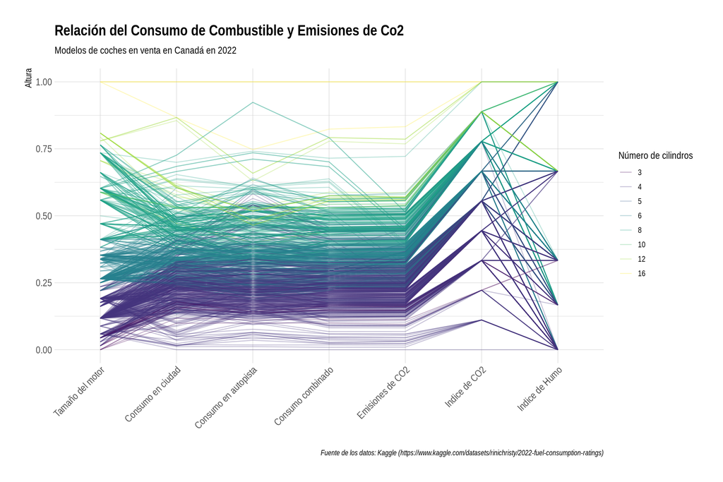

```r
parralel_plot <- fuel_data %>% ggparcoord(
    columns = 2:8,
    groupColumn = 1,
    scale="uniminmax",
    showPoints = FALSE,
    alphaLines = 0.3) +
    scale_x_discrete(guide = guide_axis(angle = 45)) +
    labs(title = "Relación del Consumo de Combustible y Emisiones de Co2",
         subtitle = "Modelos de coches en venta en Canadá en 2022",
         color = "Número de cilindros",
         caption = "Fuente de los datos: Kaggle (https://www.kaggle.com/datasets/rinichristy/2022-fuel-consumption-ratings)") +
    ylab("Altura") +
    xlab("") +
    scale_colour_viridis_d()

parralel_plot
```

# 3 Raincloud Plot

Usaremos un raincloud plot para analizar las distribuciones de las alturas de hombre y mujeres.

## 3.1 Carga y preparación de los datos

Usamos el conjunto de datos [Height of Male and Female by Country 2022](https://www.kaggle.com/datasets/majyhain/height-of-male-and-female-by-country-2022) de la [Kaggle](https://www.kaggle.com/) que contiene la altura media de hombres y mujeres por países en el año 2022

```r
alturas_original <- read.csv("datasets/Height of Male and Female by Country 2022.csv",
                  head = TRUE,
                  stringsAsFactors = FALSE,
                  blank.lines.skip = TRUE)

str(alturas_original)
```

```
## 'data.frame':    199 obs. of  6 variables:
##  $ Rank               : int  1 2 3 4 5 6 7 8 9 10 ...
##  $ Country.Name       : chr  "Netherlands" "Montenegro" "Estonia" "Bosnia and Herzegovina" ...
##  $ Male.Height.in.Cm  : num  184 183 183 182 182 ...
##  $ Female.Height.in.Cm: num  170 170 169 167 169 ...
##  $ Male.Height.in.Ft  : num  6.03 6.01 6 5.99 5.97 5.97 5.94 5.94 5.94 5.94 ...
##  $ Female.Height.in.Ft: num  5.59 5.58 5.53 5.49 5.54 5.56 5.51 5.54 5.48 5.49 ...
```

Transformamos el conjunto de datos original que viene con un formato de tabla ancha a una tabla larga.

```r
alturas <- alturas_original %>% select(Country.Name,Male.Height.in.Cm,Female.Height.in.Cm) %>%
                               pivot_longer(!Country.Name, names_to = "sexo", values_to = "altura") %>%
                               mutate (sexo = ifelse(startsWith(sexo, "Male"), "hombre", "mujer"))

str(alturas)
```

```
## tibble [398 × 3] (S3: tbl_df/tbl/data.frame)
##  $ Country.Name: chr [1:398] "Netherlands" "Netherlands" "Montenegro" "Montenegro" ...
##  $ sexo        : chr [1:398] "hombre" "mujer" "hombre" "mujer" ...
##  $ altura      : num [1:398] 184 170 183 170 183 ...
```

## 3.2 Visualización

Usamos el gráfico raincloud para analizar la distribución de las alturas y sus diferencias entre hombre y mujeres. En el código del gráfico se pueden distinguir los tres componentes del raincloud: un gráfico de (medio) violín, un gráfico de caja y un jitter plot.

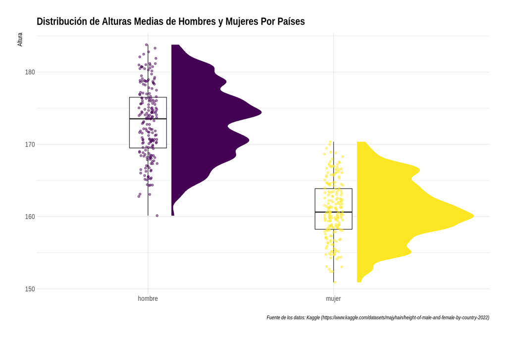

```r
ggplot(alturas, aes(x = sexo, y = altura)) +
  labs(title = "Distribución de Alturas Medias de Hombres y Mujeres Por Países",
       fill = "Sexo",
       caption = "Fuente de los datos: Kaggle (https://www.kaggle.com/datasets/majyhain/height-of-male-and-female-by-country-2022)") +
  ylab("Altura") +
  xlab("") +
  scale_fill_viridis_d() +
  scale_colour_viridis_d() +
  ggdist::stat_halfeye(aes(fill = sexo),
                       adjust = .5,
                       width = .7, .width = 0,
                       justification = -.2,
                       point_colour = NA,
                       show.legend = FALSE) +
  geom_boxplot(width = .2, outlier.shape = NA) +
  geom_jitter(aes(color=sexo), width = .05, height = 0,  alpha = .5, show.legend = FALSE)
```

Una alternativa es sustituir el jitter plot mostrar los datos en bruto de forma más ordenada, si el número de casos no es muy alto el resultado puede ser más fácil de entender y en mi opinión más bonito.

[figure not shown]

```r
ggplot(alturas, aes(x = sexo, y = altura)) +
  labs(title = "Distribución de Alturas Medias de Hombres y Mujeres Por Países",
       fill = "Sexo",
       caption = "Fuente de los datos: Kaggle (https://www.kaggle.com/datasets/majyhain/height-of-male-and-female-by-country-2022)") +
  ylab("Altura") +
  xlab("") +
  scale_fill_viridis_d() +
  scale_colour_viridis_d() +
## add half-violin from {ggdist} package
  ggdist::stat_halfeye(
    aes(fill = sexo),
    ## custom bandwidth
    adjust = .5,
    ## adjust height
    width = .6,
    ## move geom to the right
    justification = -.2,
    ## remove slab interval
    .width = 0,
    point_colour = NA,
    show.legend = FALSE
  ) +
  geom_boxplot(
    width = .12,
    ## remove outliers
    outlier.color = NA ## `outlier.shape = NA` works as well
  ) +
  ## add dot plots from {ggdist} package
  ggdist::stat_dots(
    aes(color=sexo, fill=sexo),
    ## orientation to the left
    side = "left",
    ## move geom to the left
    justification = 1.12,
    ## adjust grouping (binning) of observations
    binwidth = 0.4,
    show.legend = FALSE
  ) +
  ## remove white space on the left
  coord_cartesian(xlim = c(1.2, NA))
```